# QC Report

|  | general |
| --- | --- |
| Report generated at | 2021-01-26 11:58:54 |
| Title | POU3F2_FP-NEG_Output |
| Description | ChIP-seq for POU3F2_FP-NEG_Output |
| Pipeline version | v1.3.6 |
| Pipeline type | tf |
| Genome | hg38 |
| Aligner | bowtie2 |
| Sequencing endedness | {'rep1': {'paired_end': False}, 'rep2': {'paired_end': False}, 'ctl1': {'paired_end': False}, 'ctl2': {'paired_end': False}} |
| Peak caller | spp |

# Alignment quality metrics

## SAMstat (raw unfiltered BAM)

|  | rep1 | rep2 | ctl1 | ctl2 |
| --- | --- | --- | --- | --- |
| Total Reads | 37386755 | 34760765 | 40000000 | 40000000 |
| Total Reads (QC-failed) | 0 | 0 | 0 | 0 |
| Duplicate Reads | 0 | 0 | 0 | 0 |
| Duplicate Reads (QC-failed) | 0 | 0 | 0 | 0 |
| Mapped Reads | 34978829 | 29770489 | 39290889 | 38757911 |
| Mapped Reads (QC-failed) | 0 | 0 | 0 | 0 |
| % Mapped Reads | 93.60000000000001 | 85.6 | 98.2 | 96.89999999999999 |
| Paired Reads | 0 | 0 | 0 | 0 |
| Paired Reads (QC-failed) | 0 | 0 | 0 | 0 |
| Read1 | 0 | 0 | 0 | 0 |
| Read1 (QC-failed) | 0 | 0 | 0 | 0 |
| Read2 | 0 | 0 | 0 | 0 |
| Read2 (QC-failed) | 0 | 0 | 0 | 0 |
| Properly Paired Reads | 0 | 0 | 0 | 0 |
| Properly Paired Reads (QC-failed) | 0 | 0 | 0 | 0 |
| % Properly Paired Reads | 0.0 | 0.0 | 0.0 | 0.0 |
| With itself | 0 | 0 | 0 | 0 |
| With itself (QC-failed) | 0 | 0 | 0 | 0 |
| Singletons | 0 | 0 | 0 | 0 |
| Singletons (QC-failed) | 0 | 0 | 0 | 0 |
| % Singleton | 0.0 | 0.0 | 0.0 | 0.0 |
| Diff. Chroms | 0 | 0 | 0 | 0 |
| Diff. Chroms (QC-failed) | 0 | 0 | 0 | 0 |

## Marking duplicates (filtered BAM)

|  | rep1 | rep2 | ctl1 | ctl2 |
| --- | --- | --- | --- | --- |
| Unpaired Reads | 30255039 | 25983958 | 33371606 | 33614447 |
| Paired Reads | 0 | 0 | 0 | 0 |
| Unmapped Reads | 0 | 0 | 0 | 0 |
| Unpaired Duplicate Reads | 2627154 | 5079492 | 909987 | 1692598 |
| Paired Duplicate Reads | 0 | 0 | 0 | 0 |
| Paired Optical Duplicate Reads | 0 | 0 | 0 | 0 |
| % Duplicate Reads | 8.683399999999999 | 19.5486 | 2.7268 | 5.0353 |

Filtered out (samtools view -F 1804):

- read unmapped (0x4)
- mate unmapped (0x8, for paired-end)
- not primary alignment (0x100)
- read fails platform/vendor quality checks (0x200)
- read is PCR or optical duplicate (0x400)

## SAMstat (filtered/deduped BAM)

|  | rep1 | rep2 | ctl1 | ctl2 |
| --- | --- | --- | --- | --- |
| Total Reads | 27627885 | 20904466 | 32461619 | 31921849 |
| Total Reads (QC-failed) | 0 | 0 | 0 | 0 |
| Duplicate Reads | 0 | 0 | 0 | 0 |
| Duplicate Reads (QC-failed) | 0 | 0 | 0 | 0 |
| Mapped Reads | 27627885 | 20904466 | 32461619 | 31921849 |
| Mapped Reads (QC-failed) | 0 | 0 | 0 | 0 |
| % Mapped Reads | 100.0 | 100.0 | 100.0 | 100.0 |
| Paired Reads | 0 | 0 | 0 | 0 |
| Paired Reads (QC-failed) | 0 | 0 | 0 | 0 |
| Read1 | 0 | 0 | 0 | 0 |
| Read1 (QC-failed) | 0 | 0 | 0 | 0 |
| Read2 | 0 | 0 | 0 | 0 |
| Read2 (QC-failed) | 0 | 0 | 0 | 0 |
| Properly Paired Reads | 0 | 0 | 0 | 0 |
| Properly Paired Reads (QC-failed) | 0 | 0 | 0 | 0 |
| % Properly Paired Reads | 0.0 | 0.0 | 0.0 | 0.0 |
| With itself | 0 | 0 | 0 | 0 |
| With itself (QC-failed) | 0 | 0 | 0 | 0 |
| Singletons | 0 | 0 | 0 | 0 |
| Singletons (QC-failed) | 0 | 0 | 0 | 0 |
| % Singleton | 0.0 | 0.0 | 0.0 | 0.0 |
| Diff. Chroms | 0 | 0 | 0 | 0 |
| Diff. Chroms (QC-failed) | 0 | 0 | 0 | 0 |

Filtered and duplicates removed

## Sequence quality metrics (filtered/deduped BAM)

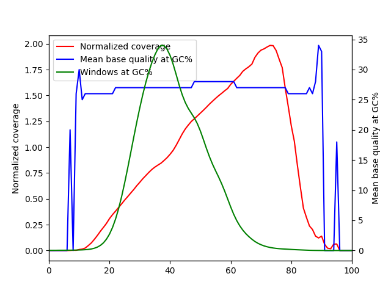

rep1

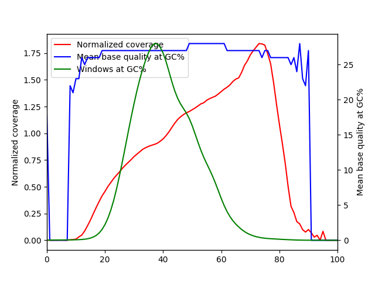

rep2

Open chromatin assays are known to have significant GC bias. Please take this into consideration as necessary.

# Library complexity quality metrics

## Library complexity (filtered non-mito BAM)

|  | rep1 | rep2 | ctl1 | ctl2 |
| --- | --- | --- | --- | --- |
| Total Fragments | 30251297 | 25980730 | 33370019 | 33607988 |
| Distinct Fragments | 27664824 | 20946747 | 32585938 | 31972703 |
| Positions with Two Read | 2190379 | 3475096 | 753555 | 1490125 |
| NRF = Distinct/Total | 0.9145 | 0.806242 | 0.976503 | 0.951342 |
| PBC1 = OneRead/Distinct | 0.913984 | 0.799992 | 0.976432 | 0.951223 |
| PBC2 = OneRead/TwoRead | 11.543758 | 4.82209 | 42.223775 | 20.409807 |

Mitochondrial reads are filtered out by default. The non-redundant fraction (NRF) is the fraction of non-redundant mapped reads in a dataset; it is the ratio between the number of positions in the genome that uniquely mapped reads map to and the total number of uniquely mappable reads. The NRF should be > 0.8. The PBC1 is the ratio of genomic locations with EXACTLY one read pair over the genomic locations with AT LEAST one read pair. PBC1 is the primary measure, and the PBC1 should be close to 1. Provisionally 0-0.5 is severe bottlenecking, 0.5-0.8 is moderate bottlenecking, 0.8-0.9 is mild bottlenecking, and 0.9-1.0 is no bottlenecking. The PBC2 is the ratio of genomic locations with EXACTLY one read pair over the genomic locations with EXACTLY two read pairs. The PBC2 should be significantly greater than 1. See more details at [the ENCODE portal standard for ChIP-Seq pipeline](https://www.encodeproject.org/chip-seq/transcription_factor/#standards)

NRF (non redundant fraction)  
PBC1 (PCR Bottleneck coefficient 1)  
PBC2 (PCR Bottleneck coefficient 2)  
PBC1 is the primary measure. Provisionally

- 0-0.5 is severe bottlenecking
- 0.5-0.8 is moderate bottlenecking
- 0.8-0.9 is mild bottlenecking
- 0.9-1.0 is no bottlenecking

# Replication quality metrics

## IDR (Irreproducible Discovery Rate) plots

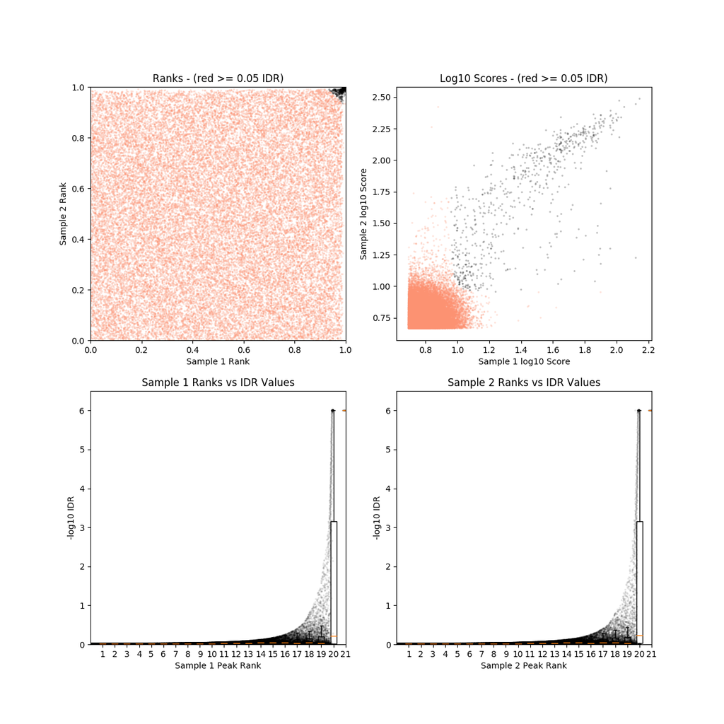

rep1_vs_rep2

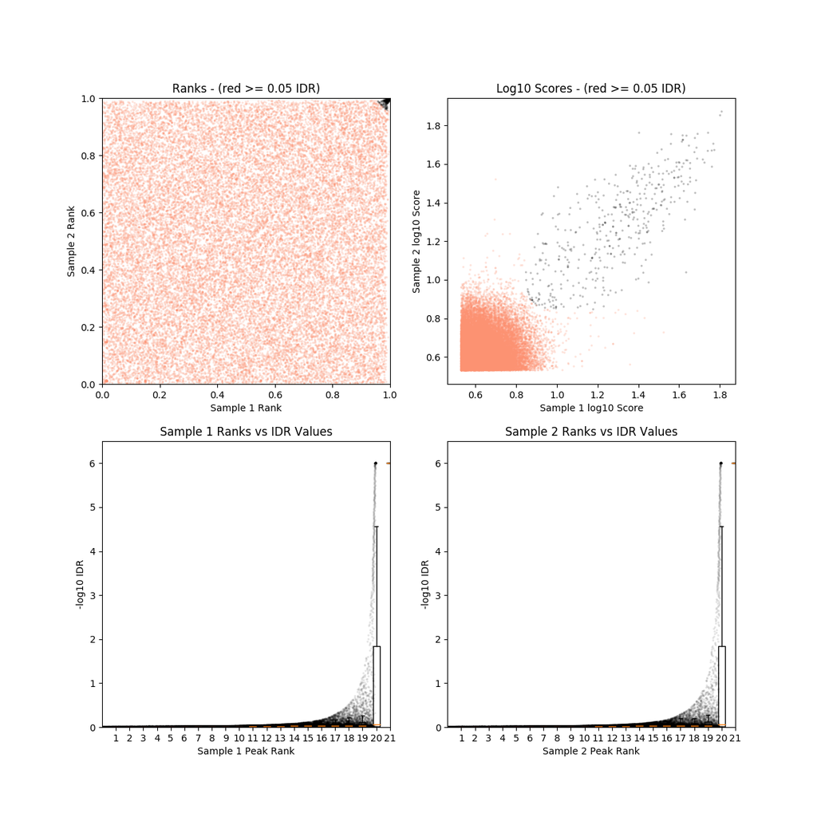

rep1-pr1_vs_rep1-pr2

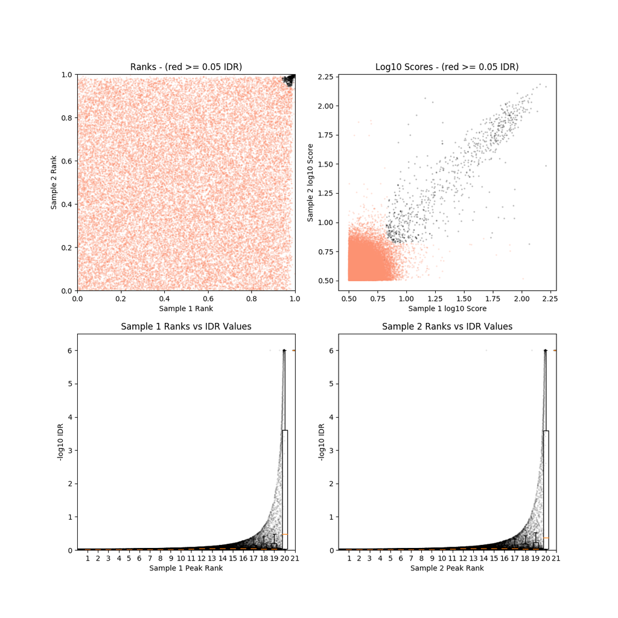

rep2-pr1_vs_rep2-pr2

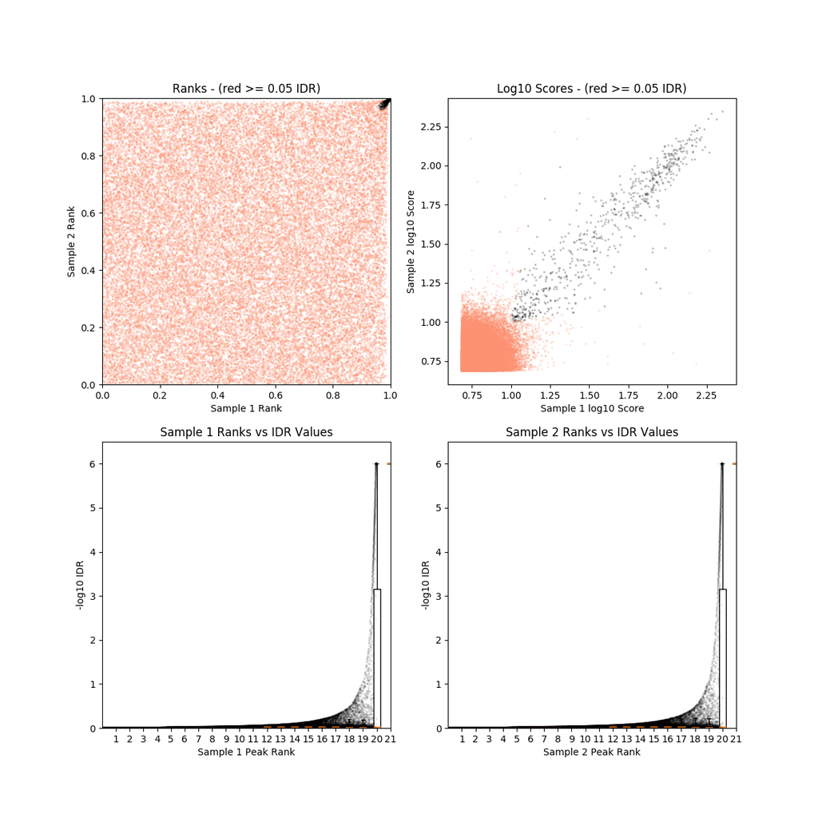

pooled-pr1_vs_pooled-pr2

## Reproducibility QC and peak detection statistics

|  | overlap | idr |
| --- | --- | --- |
| Nt | 27387 | 667 |
| N1 | 20754 | 415 |
| N2 | 25001 | 816 |
| Np | 30780 | 679 |
| N optimal | 30780 | 679 |
| N conservative | 27387 | 667 |
| Optimal Set | pooled-pr1_vs_pooled-pr2 | pooled-pr1_vs_pooled-pr2 |
| Conservative Set | rep1_vs_rep2 | rep1_vs_rep2 |
| Rescue Ratio | 1.1238908971409793 | 1.0179910044977512 |
| Self Consistency Ratio | 1.2046352510359448 | 1.966265060240964 |
| Reproducibility Test | pass | pass |

Reproducibility QC

- N1: Replicate 1 self-consistent peaks (comparing two pseudoreplicates generated by subsampling Rep1 reads)
- N2: Replicate 2 self-consistent peaks (comparing two pseudoreplicates generated by subsampling Rep2 reads)
- Ni: Replicate i self-consistent peaks (comparing two pseudoreplicates generated by subsampling RepX reads)
- Nt: True Replicate consistent peaks (comparing true replicates Rep1 vs Rep2)
- Np: Pooled-pseudoreplicate consistent peaks (comparing two pseudoreplicates generated by subsampling pooled reads from Rep1 and Rep2)
- Self-consistency Ratio: max(N1,N2) / min (N1,N2)
- Rescue Ratio: max(Np,Nt) / min (Np,Nt)
- Reproducibility Test: If Self-consistency Ratio >2 AND Rescue Ratio > 2, then 'Fail' else 'Pass'

## Number of raw peaks

|  | rep1 | rep2 |
| --- | --- | --- |
| Number of peaks | 299979 | 299969 |

Top 300000 raw peaks from spp with FDR 0.01

# Peak calling statistics

## Peak region size

|  | rep1 | rep2 | idr_opt | overlap_opt |
| --- | --- | --- | --- | --- |
| Min size | 84.0 | 106.0 | 102.0 | 102.0 |
| 25 percentile | 336.0 | 424.0 | 247.0 | 410.0 |
| 50 percentile (median) | 336.0 | 424.0 | 410.0 | 410.0 |
| 75 percentile | 336.0 | 424.0 | 410.0 | 410.0 |
| Max size | 336.0 | 475.0 | 464.0 | 469.0 |
| Mean | 335.9732114581354 | 423.8192013174695 | 331.7290132547864 | 408.2659194282001 |

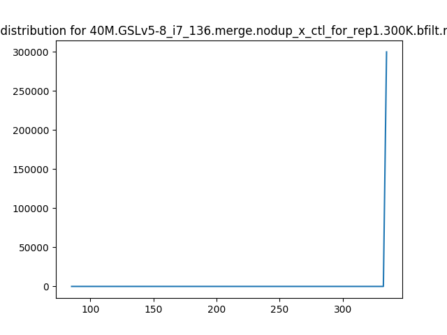

rep1

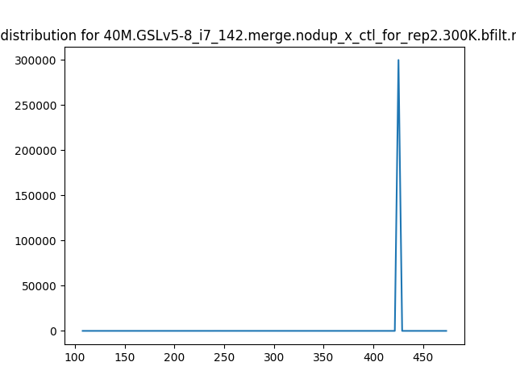

rep2

[figure not shown]

idr_opt

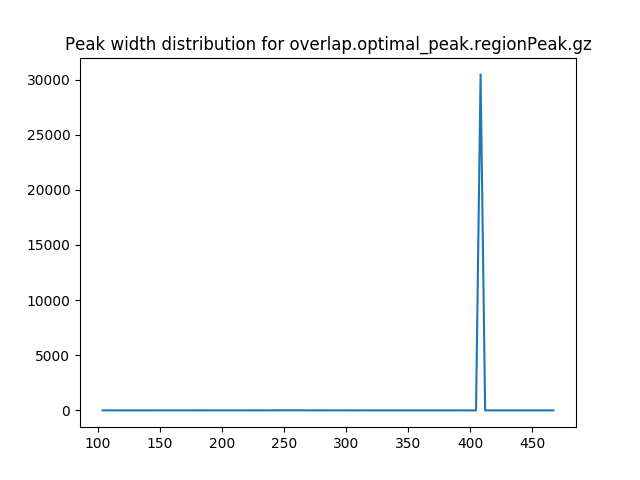

overlap_opt

# Enrichment / Signal-to-noise ratio

## Strand cross-correlation measures (trimmed/filtered SE BAM)

|  | rep1 | rep2 |
| --- | --- | --- |
| Number of Subsampled Reads | 15000000 | 15000000 |
| Estimated Fragment Length | 110 | 125 |
| Cross-correlation at Estimated Fragment Length | 0.161978389038105 | 0.146351904312776 |
| Phantom Peak | 100 | 105 |
| Cross-correlation at Phantom Peak | 0.1620485 | 0.146241 |
| Argmin of Cross-correlation | 1500 | 1500 |
| Minimum of Cross-correlation | 0.1584134 | 0.1387834 |
| NSC (Normalized Strand Cross-correlation coeff.) | 1.022504 | 1.054535 |
| RSC (Relative Strand Cross-correlation coeff.) | 0.9807037 | 1.014871 |

Performed on subsampled (15000000) reads mapped from FASTQs that are trimmed to 50. Such FASTQ trimming and subsampling reads are for cross-corrleation analysis only. Untrimmed FASTQs are used for all the other analyses.

NOTE1: For SE datasets, reads from replicates are randomly subsampled to 15000000.  
NOTE2: For PE datasets, the first end (R1) of each read-pair is selected and trimmed to 50 the reads are then randomly subsampled to 15000000.

- Normalized strand cross-correlation coefficient (NSC) = col9 in outFile
- Relative strand cross-correlation coefficient (RSC) = col10 in outFile
- Estimated fragment length = col3 in outFile, take the top value

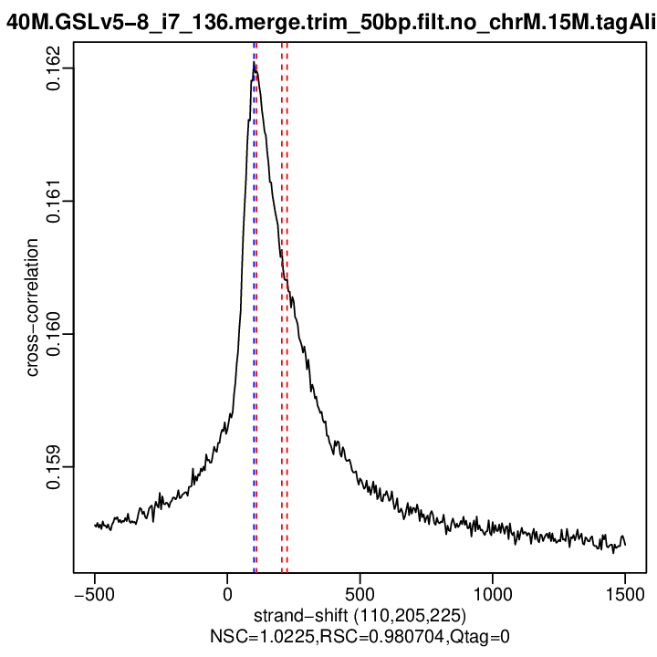

rep1

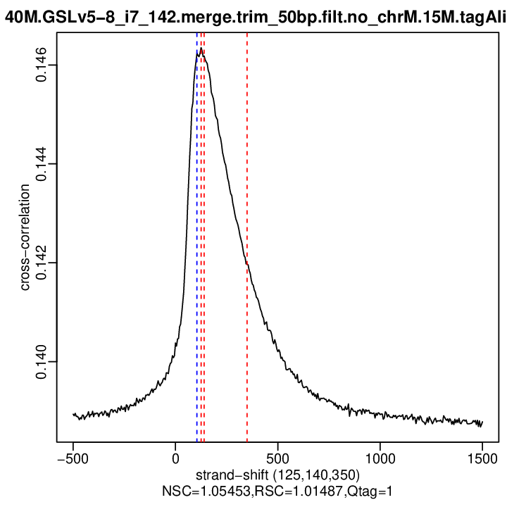

rep2

## Jensen-Shannon distance (filtered/deduped BAM)

|  | rep1 | rep2 |
| --- | --- | --- |
| AUC | 0.3048755627989746 | 0.2937123397852323 |
| Synthetic AUC | 0.4932167490338192 | 0.4922439849821255 |
| X-intercept | 0.10822901251849779 | 0.12607087149542054 |
| Synthetic X-intercept | 5.215006501618201e-186 | 5.909531250461479e-142 |
| Elbow Point | 0.5387293524777027 | 0.5474923009238891 |
| Synthetic Elbow Point | 0.4993300131353602 | 0.4927862088871968 |
| JS Distance | 0.018612883704238456 | 0.03623933326484624 |
| Synthetic JS Distance | 0.22763036141997695 | 0.23434764152910273 |
| % Genome Enriched | 39.00191976962765 | 38.058632964044314 |
| Diff. Enrichment | 14.926583460364306 | 18.990725063535248 |
| CHANCE Divergence | 0.12908566309301142 | 0.16369889043767355 |

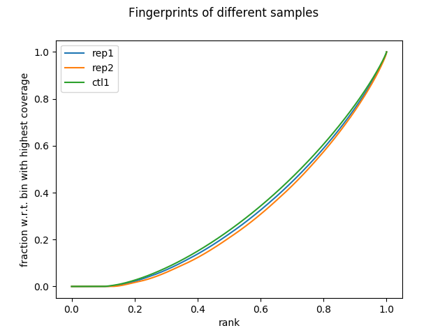

# Peak enrichment

## Fraction of reads in peaks (FRiP)

### FRiP for spp raw peaks

|  | rep1 | rep2 | rep1-pr1 | rep2-pr1 | rep1-pr2 | rep2-pr2 | pooled | pooled-pr1 | pooled-pr2 |
| --- | --- | --- | --- | --- | --- | --- | --- | --- | --- |
| Fraction of Reads in Peaks | 0.10274995715379588 | 0.12011897362027808 | 0.12331555154093223 | 0.14205117700686543 | 0.1236481954245935 | 0.1418960905291721 | 0.09483086858907783 | 0.10828265648448276 | 0.10878405846821759 |

### FRiP for overlap peaks

|  | rep1_vs_rep2 | rep1-pr1_vs_rep1-pr2 | rep2-pr1_vs_rep2-pr2 | pooled-pr1_vs_pooled-pr2 |
| --- | --- | --- | --- | --- |
| Fraction of Reads in Peaks | 0.01237562136645719 | 0.009775522085747787 | 0.01554246829361726 | 0.013468273976671767 |

### FRiP for IDR peaks

|  | rep1_vs_rep2 | rep1-pr1_vs_rep1-pr2 | rep2-pr1_vs_rep2-pr2 | pooled-pr1_vs_pooled-pr2 |
| --- | --- | --- | --- | --- |
| Fraction of Reads in Peaks | 0.0019889413558391187 | 0.0010027912017152236 | 0.0033037916395472623 | 0.0020237016747859586 |

For spp raw peaks:

- repX: Peak from true replicate X
- repX-prY: Peak from Yth pseudoreplicates from replicate X
- pooled: Peak from pooled true replicates (pool of rep1, rep2, ...)
- pooled-pr1: Peak from 1st pooled pseudo replicate (pool of rep1-pr1, rep2-pr1, ...)
- pooled-pr2: Peak from 2nd pooled pseudo replicate (pool of rep1-pr2, rep2-pr2, ...)

For overlap/IDR peaks:

- repX_vs_repY: Comparing two peaks from true replicates X and Y
- repX-pr1_vs_repX-pr2: Comparing two peaks from both pseudoreplicates from replicate X
- pooled-pr1_vs_pooled-pr2: Comparing two peaks from 1st and 2nd pooled pseudo replicates